# Bike Sharing demand prediction

Mathematics in Machine Learning

Giacomo Zema

# 1 dev environment

the project is a R notebook with R markdown this are the r packages used

```r
library(tidyverse)
```

```r
library(ggplot2)
library(psych)
library(ggpubr)
library(car)
library(MASS)
```

# 2 the dataset

dataset visualization and data

seoul bike sharing demand dataset

```r
bikes.old <- read.csv(file="C:\\Users\\Giacomo\\Desktop\\mml\\SeoulBikeData.csv")
head(bikes.old)
```

|  | Date | Count | Hour | Temp | Hum | Wind | Visibility | Dew | Solar | Rain | Snow | Seasons | Holiday | Func |
| --- | --- | --- | --- | --- | --- | --- | --- | --- | --- | --- | --- | --- | --- | --- |
| 1 | 01/12/2017 | 254 | 0 | -5.2 | 37 | 2.2 | 2000 | -17.6 | 0 | 0 | 0 | Winter | No Holiday | Yes |
| 2 | 01/12/2017 | 204 | 1 | -5.5 | 38 | 0.8 | 2000 | -17.6 | 0 | 0 | 0 | Winter | No Holiday | Yes |
| 3 | 01/12/2017 | 173 | 2 | -6.0 | 39 | 1.0 | 2000 | -17.7 | 0 | 0 | 0 | Winter | No Holiday | Yes |
| 4 | 01/12/2017 | 107 | 3 | -6.2 | 40 | 0.9 | 2000 | -17.6 | 0 | 0 | 0 | Winter | No Holiday | Yes |
| 5 | 01/12/2017 | 78 | 4 | -6.0 | 36 | 2.3 | 2000 | -18.6 | 0 | 0 | 0 | Winter | No Holiday | Yes |
| 6 | 01/12/2017 | 100 | 5 | -6.4 | 37 | 1.5 | 2000 | -18.7 | 0 | 0 | 0 | Winter | No Holiday | Yes |

```r
bikes.old$wday <- as.POSIXlt(bikes.old$Date, format = '%d/%m/%Y')$wday


bikes <- bikes.old %>%
  separate(Date, sep="/", into = c("day", "month", "year"))

head(bikes)
```

|  | day | month | year | Count | Hour | Temp | Hum | Wind | Visibility | Dew | Solar | Rain | Snow | Seasons | Holiday | Func | wday |
| --- | --- | --- | --- | --- | --- | --- | --- | --- | --- | --- | --- | --- | --- | --- | --- | --- | --- |
| 1 | 01 | 12 | 2017 | 254 | 0 | -5.2 | 37 | 2.2 | 2000 | -17.6 | 0 | 0 | 0 | Winter | No Holiday | Yes | 5 |
| 2 | 01 | 12 | 2017 | 204 | 1 | -5.5 | 38 | 0.8 | 2000 | -17.6 | 0 | 0 | 0 | Winter | No Holiday | Yes | 5 |
| 3 | 01 | 12 | 2017 | 173 | 2 | -6.0 | 39 | 1.0 | 2000 | -17.7 | 0 | 0 | 0 | Winter | No Holiday | Yes | 5 |
| 4 | 01 | 12 | 2017 | 107 | 3 | -6.2 | 40 | 0.9 | 2000 | -17.6 | 0 | 0 | 0 | Winter | No Holiday | Yes | 5 |
| 5 | 01 | 12 | 2017 | 78 | 4 | -6.0 | 36 | 2.3 | 2000 | -18.6 | 0 | 0 | 0 | Winter | No Holiday | Yes | 5 |
| 6 | 01 | 12 | 2017 | 100 | 5 | -6.4 | 37 | 1.5 | 2000 | -18.7 | 0 | 0 | 0 | Winter | No Holiday | Yes | 5 |

```r
to_wend <- function(wday){
  if(wday==6 | wday==0){
    wend = 1
  } else {
    wend = 0
  }
}

bikes$wend = sapply(bikes$wday, to_wend)
head(bikes)
```

|  | day | month | year | Count | Hour | Temp | Hum | Wind | Visibility | Dew | Solar | Rain | Snow | Seasons | Holiday | Func | wday | wend |
| --- | --- | --- | --- | --- | --- | --- | --- | --- | --- | --- | --- | --- | --- | --- | --- | --- | --- | --- |
| 1 | 01 | 12 | 2017 | 254 | 0 | -5.2 | 37 | 2.2 | 2000 | -17.6 | 0 | 0 | 0 | Winter | No Holiday | Yes | 5 | 0 |
| 2 | 01 | 12 | 2017 | 204 | 1 | -5.5 | 38 | 0.8 | 2000 | -17.6 | 0 | 0 | 0 | Winter | No Holiday | Yes | 5 | 0 |
| 3 | 01 | 12 | 2017 | 173 | 2 | -6.0 | 39 | 1.0 | 2000 | -17.7 | 0 | 0 | 0 | Winter | No Holiday | Yes | 5 | 0 |
| 4 | 01 | 12 | 2017 | 107 | 3 | -6.2 | 40 | 0.9 | 2000 | -17.6 | 0 | 0 | 0 | Winter | No Holiday | Yes | 5 | 0 |
| 5 | 01 | 12 | 2017 | 78 | 4 | -6.0 | 36 | 2.3 | 2000 | -18.6 | 0 | 0 | 0 | Winter | No Holiday | Yes | 5 | 0 |
| 6 | 01 | 12 | 2017 | 100 | 5 | -6.4 | 37 | 1.5 | 2000 | -18.7 | 0 | 0 | 0 | Winter | No Holiday | Yes | 5 | 0 |

the response variable is the hourly rented bike count

plot the histogram of the response

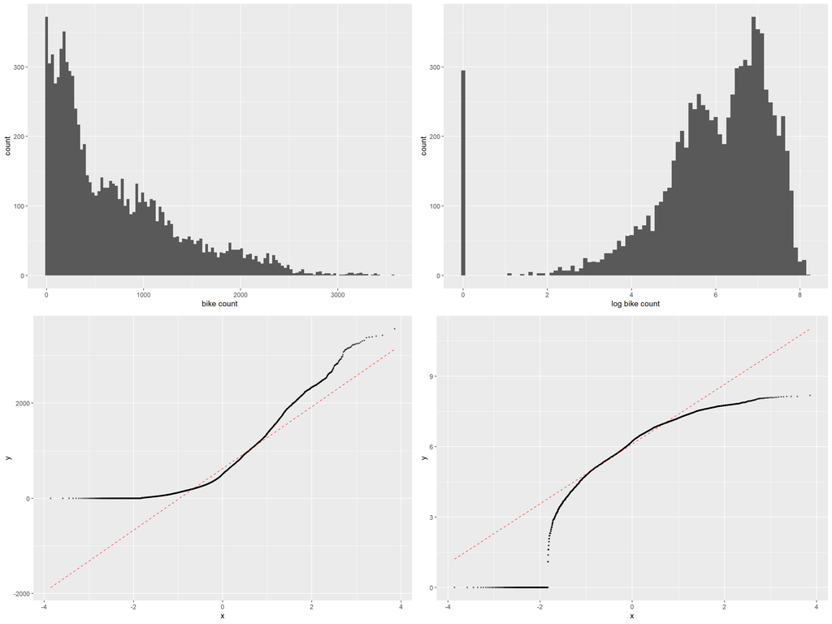

```r
resp <- ggplot(data=bikes) +
  geom_histogram(aes(Count), binwidth = 30) +
  xlab("bike count")

resp_log <- ggplot(data=bikes) +
  geom_histogram(aes(log(Count+1)), binwidth = 0.1) +
  xlab("log bike count")

resp_qq <- ggplot(data=bikes, aes(sample = Count))+
  geom_qq(alpha = 0.5, size=0.8) +
  stat_qq_line(color="red", alpha=0.7, size=0.5, linetype=2)

resp_qq_log <- ggplot(data=bikes, aes(sample = log(Count+1)))+
  geom_qq(alpha = 0.5, size=0.8) +
  stat_qq_line(color="red", alpha=0.7, size=0.5, linetype=2)

ggarrange(resp, resp_log, resp_qq, resp_qq_log, ncol = 2, nrow = 2)
```

the situation improves with the log transformation, but there are many zero values

visualize the data with plots

plot the correlation between quantitative attributes

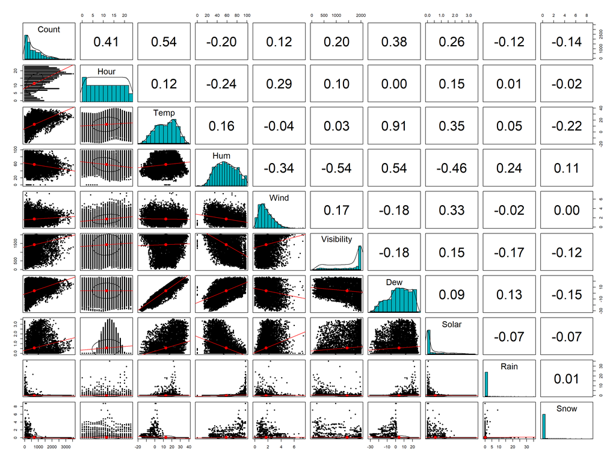

```r
bikes.quant = subset(bikes.old, select=-c(Date, Seasons, Holiday, Func, wday))


pairs.panels(bikes.quant,
             method = "pearson",
             hist.col = "#00AFBB",
             density = TRUE,  # show density plots
             ellipses = TRUE, # show correlation ellipses
             lm=TRUE #Plot the linear fit rather than the LOESS smoothed fits.
             )
```

average user count by hour of the day

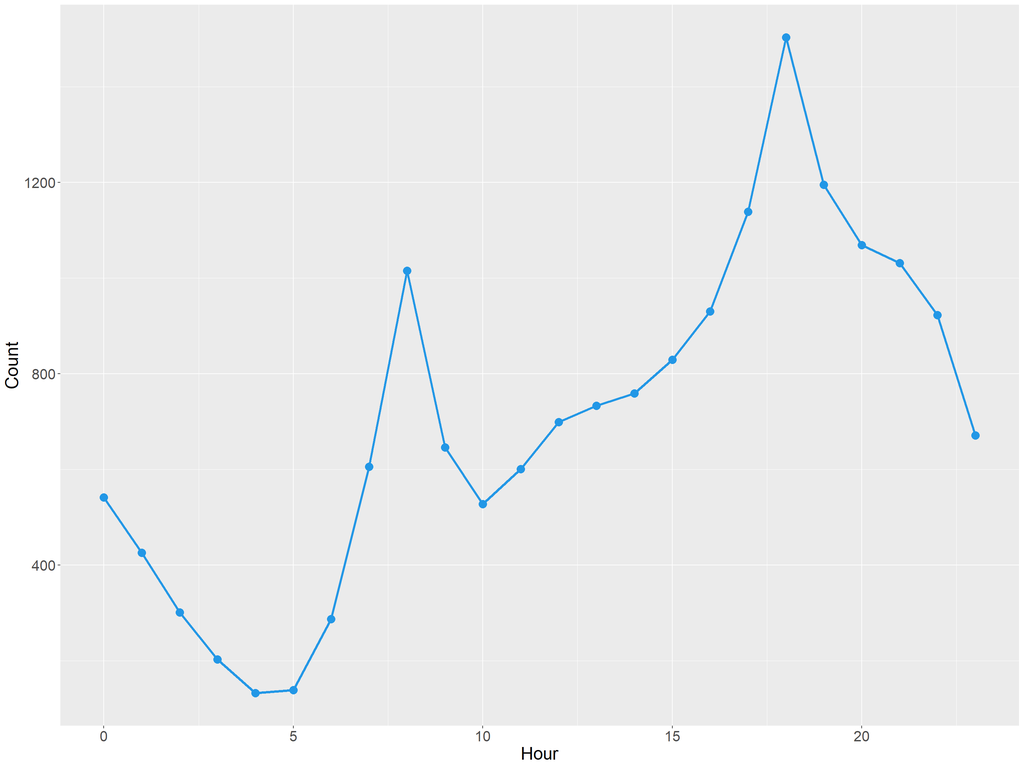

```r
means <- aggregate(Count ~ Hour, bikes, mean)

ggplot(means, aes(x=Hour, y = Count))+
  theme(text = element_text(size=20))+
  geom_line(size=1.3, colour="92") + geom_point(size=4, colour="92")
```

average user count by hour across years

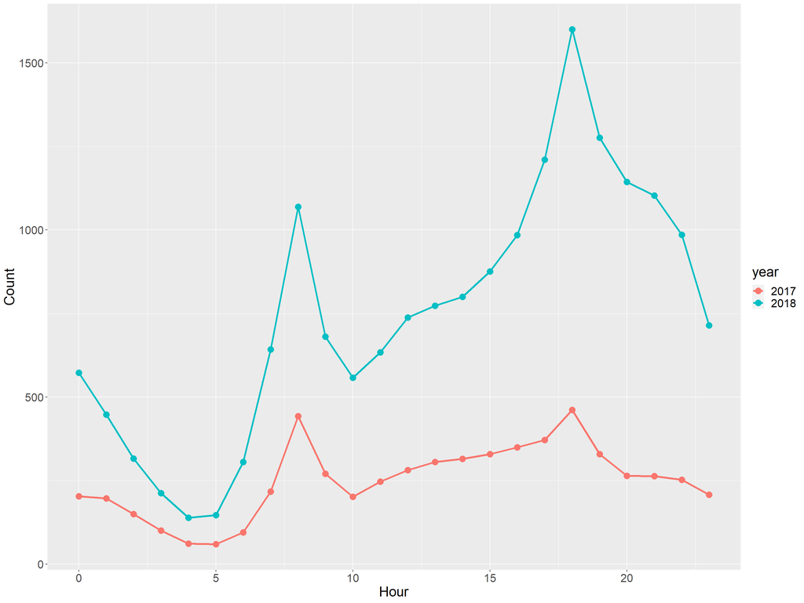

```r
bikes17 <-subset(bikes, bikes$year=="2017")
bikes18 <-subset(bikes, bikes$year=="2018")
means17 <- aggregate(Count ~ Hour, bikes17, mean)
means18 <- aggregate(Count ~ Hour, bikes18, mean)

means18$year <- "2018"
means17$year<-"2017"
means_year <- rbind(means17, means18)


ggplot(means_year, aes(x=Hour, y = Count, colour = year))+
  theme(text = element_text(size=20))+
  geom_line(size=1.3) + geom_point(size=4)
```

we can see that the average hourly count follows the same trend, but the average number is lower for year 2017, this is due to the fact that the dataset contains only the last month of 2017 and 11 months of 2018 as we can see the total number of rows for year 2017 is much lower than 2018. Another important difference is that the month of December that is the only one for 2017, is one of the coldest of the year and from the correlation measures we observed how the count and the temperature are positively correlated, so lower temperature results in lower count, we can understand this aspect better if we display the average hourly count for the year 2017 and the month of January of 2018.

Because of the previous observations I will exclude the year as a feature for the regression model.

count the total number of rows for each year

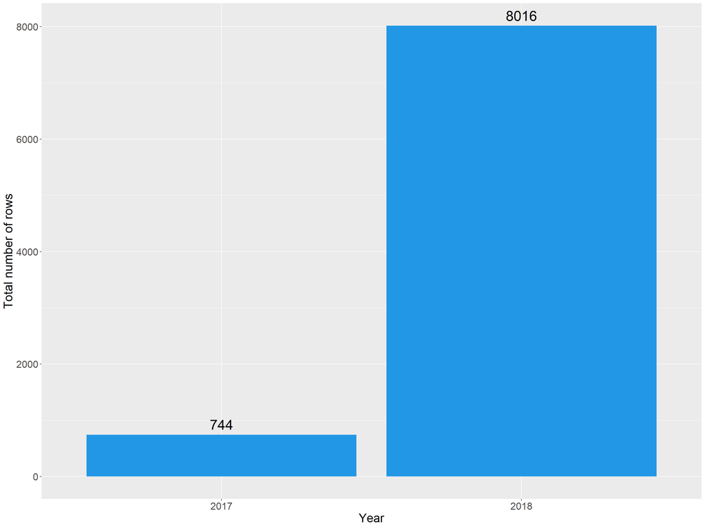

```r
tot17 <- nrow(bikes17)
tot18 <- nrow(bikes18)


tot <- c(tot17, tot18)
year <- c("2017", "2018")

tot_year <- data.frame(tot, year)

bikes18_jan <-subset(bikes, bikes$year=="2018" & bikes$month=="01")

means18_jan <- aggregate(Count ~ Hour, bikes18_jan, mean)
means18_jan$year <- "2018"
means_y2 <- rbind(means17, means18_jan)

ggplot(tot_year, aes(x=year, y=tot, label=tot))+
  geom_bar(stat="identity", fill="92")+
  labs(y="Total number of rows", x="Year")+
  theme(text = element_text(size=20))+
  geom_text(position=position_dodge(1), vjust=-0.5, size=8)
```

plot the average hourly count for the month of january 2018 and the month of december 2017 here we can see the year itself does not contribute to the response as much as the month

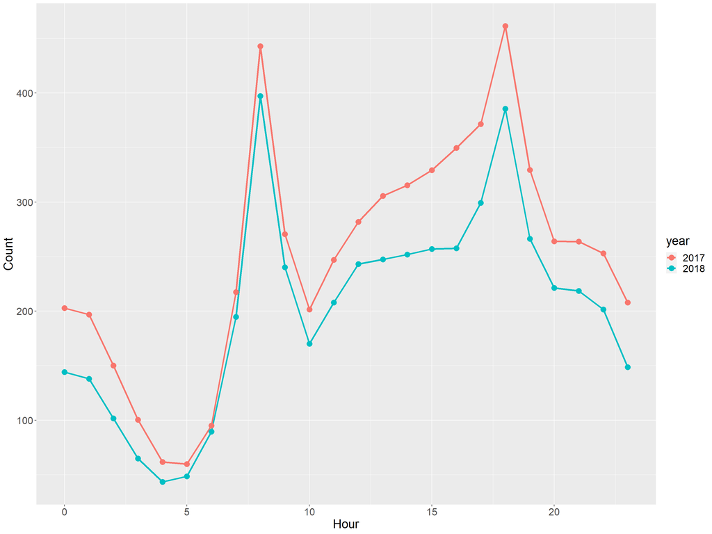

```r
ggplot(means_y2, aes(x=Hour, y = Count, colour = year))+
  theme(text = element_text(size=20))+
  geom_line(size=1.3) + geom_point(size=4)
```

plot average count by month

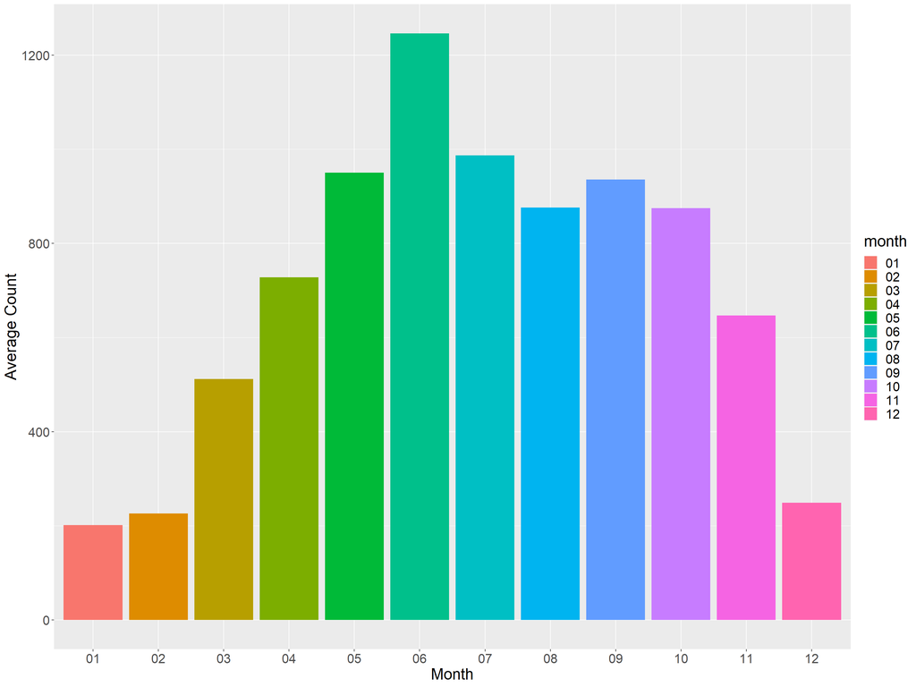

```r
means_month <- aggregate(Count~month, bikes, mean)

ggplot(means_month, aes(x=month, y=Count, fill=month))+
  geom_bar(stat="identity")+
  theme(text = element_text(size=20))+
  labs(y="Average Count", x="Month")
```

plot average hourly count across months

we can observe that the hourly trend is similar across months, what changes is obviously the actual count.

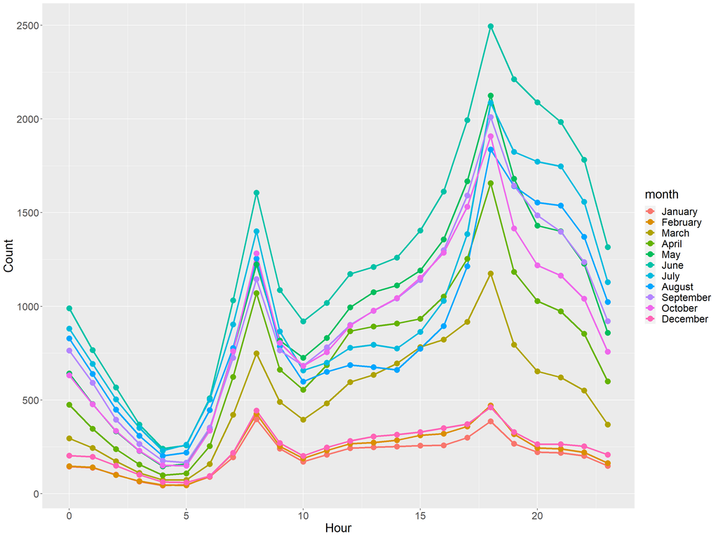

```r
bikes.jan <-subset(bikes, bikes$month=="01")
bikes.feb <-subset(bikes, bikes$month=="02")
bikes.mar <-subset(bikes, bikes$month=="03")
bikes.apr <-subset(bikes, bikes$month=="04")
bikes.may <-subset(bikes, bikes$month=="05")
bikes.jun <-subset(bikes, bikes$month=="06")
bikes.jul <-subset(bikes, bikes$month=="07")
bikes.aug <-subset(bikes, bikes$month=="08")
bikes.sep <-subset(bikes, bikes$month=="09")
bikes.oct <-subset(bikes, bikes$month=="10")
bikes.nov <-subset(bikes, bikes$month=="11")
bikes.dec <-subset(bikes, bikes$month=="12")

means.jan <- aggregate(Count ~ Hour, bikes.jan, mean)
means.feb <- aggregate(Count ~ Hour, bikes.feb, mean)
means.mar <- aggregate(Count ~ Hour, bikes.mar, mean)
means.apr <- aggregate(Count ~ Hour, bikes.apr, mean)
means.may <- aggregate(Count ~ Hour, bikes.may, mean)
means.jun <- aggregate(Count ~ Hour, bikes.jun, mean)
means.jul <- aggregate(Count ~ Hour, bikes.jul, mean)
means.aug <- aggregate(Count ~ Hour, bikes.aug, mean)
means.sep <- aggregate(Count ~ Hour, bikes.sep, mean)
means.oct <- aggregate(Count ~ Hour, bikes.oct, mean)
means.nov <- aggregate(Count ~ Hour, bikes.nov, mean)
means.dec <- aggregate(Count ~ Hour, bikes.dec, mean)

means.jan$month <- "January"
means.feb$month <- "February"
means.mar$month <- "March"
means.apr$month <- "April"
means.may$month <- "May"
means.jun$month <- "June"
means.jul$month <- "July"
means.aug$month <- "August"
means.sep$month <- "September"
means.oct$month <- "October"
means.nov$month <- "November"
means.dec$month <- "December"


means_month <- rbind(means.jan, means.feb, means.mar, means.apr, means.may, means.jun, means.jul, means.aug, means.sep, means.oct, means.dec)

means_month$month <- factor(means_month$month, levels= c("January", "February", "March", "April", "May", "June", "July", "August", "September", "October", "November", "December"))

ggplot(means_month, aes(x=Hour, y = Count, colour = month))+
  theme(text = element_text(size=20), legend.position = "right")+
  geom_line(size=1.3) + geom_point(size=4)
```

plot average user count by hour across seasons

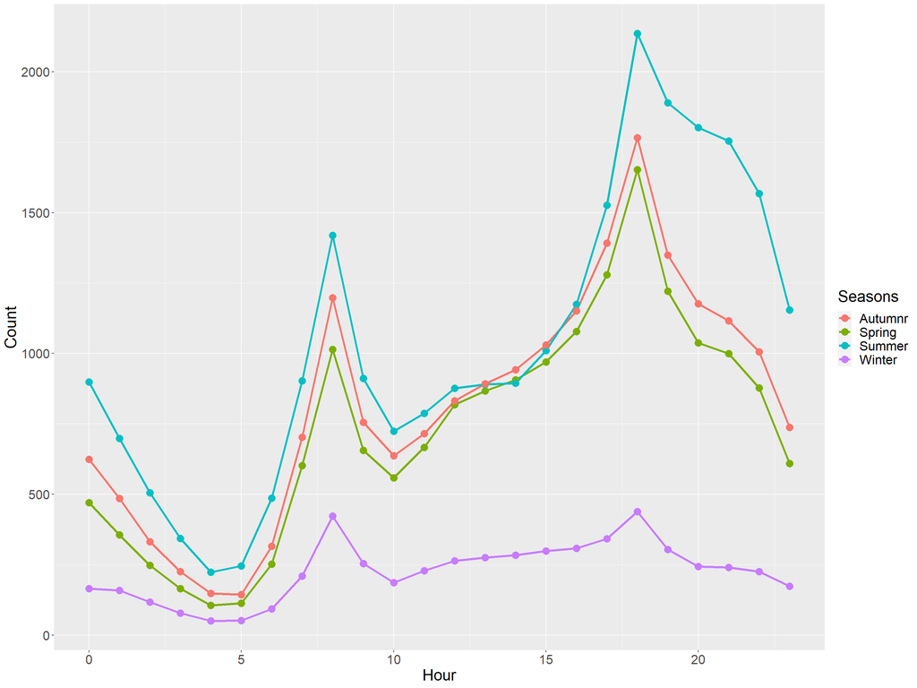

```r
bikes.winter <-subset(bikes, bikes$Seasons=="Winter")
bikes.spring <-subset(bikes, bikes$Seasons=="Spring")
bikes.summer <-subset(bikes, bikes$Seasons=="Summer")
bikes.autumn <-subset(bikes, bikes$Seasons=="Autumn")

means.winter <- aggregate(Count ~ Hour, bikes.winter, mean)
means.spring <- aggregate(Count ~ Hour, bikes.spring, mean)
means.summer <- aggregate(Count ~ Hour, bikes.summer, mean)
means.autumn <- aggregate(Count ~ Hour, bikes.autumn, mean)

means.winter$Seasons <- "Winter"
means.spring$Seasons <- "Spring"
means.summer$Seasons <- "Summer"
means.autumn$Seasons <- "Autumnr"

means_seasons <- rbind(means.winter, means.spring, means.summer, means.autumn)


ggplot(means_seasons, aes(x=Hour, y = Count, colour = Seasons))+
  theme(text = element_text(size=20))+
  geom_line(size=1.3) + geom_point(size=4)
```

plot average user count by hour across week days and week end

we can see hour the spikes corresponding to rush hours are no longer present, because people are not commuting to work on weekends, while the count is higher during the night and in the hours during which people are usually working (from 10 to 17). From the paper attached to the dataset I observed the graph showing the average users count by hour across all days of the week and observed how all weekdays have very similar hourly counts and those of saturday and sunday are very close to each other, so I concluded that having only two factors instead of seven was the better choice.

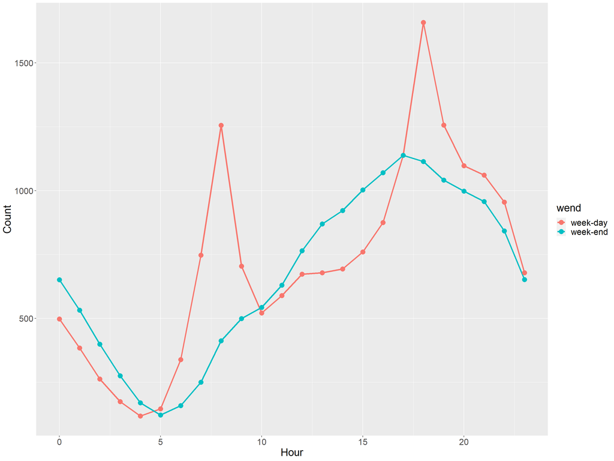

```r
bikes.wday <-subset(bikes, bikes$wend==0)
bikes.wend <-subset(bikes, bikes$wend==1)
means.wday <- aggregate(Count ~ Hour, bikes.wday, mean)
means.wend <- aggregate(Count ~ Hour, bikes.wend, mean)

means.wday$wend <- "week-day"
means.wend$wend <- "week-end"
means_wend <- rbind(means.wday, means.wend)


ggplot(means_wend, aes(x=Hour, y = Count, colour = wend))+
  theme(text = element_text(size=20))+
  geom_line(size=1.3) + geom_point(size=4)
```